# FordGO Dataset Visualization

## Introduction

This data set includes information about individual rides made in a bike-sharing system covering the greater San Francisco Bay area. Ford GoBike is the Bay Area's bike share system. Bay Area Bike Share was introduced in 2013 as a pilot program for the region, with 700 bikes and 70 stations across San Francisco and San Jose. Once expansion is complete, Ford GoBike will grow to 7,000 bikes across San Francisco, the East Bay and San Jose.

Ford GoBike, like other bike share systems, consists of a fleet of specially designed, sturdy and durable bikes that are locked into a network of docking stations throughout the city. The bikes can be unlocked from one station and returned to any other station in the system, making them ideal for one-way trips. People use bike share to commute to work or school, run errands, get to appointments or social engagements and more. It's a fun, convenient and affordable way to get around.

The bikes are available for use 24 hours/day, 7 days/week, 365 days/year and riders have access to all bikes in the network when they become a member or purchase a pass.

[figure not shown]

```python
from IPython.display import Image
Image('ford_gobike.jpg')
```

## Preliminary Wrangling

```python
# import all necessary library
import numpy as np
import pandas as pd
import matplotlib.pyplot as plt
import seaborn as sns

%matplotlib inline
```

```python
# Reading the downloaded dataset
df = pd.read_csv('2017-fordgo.csv')
df.head(10)
```

|  | duration_sec | start_time | end_time | start_station_id | start_station_name | start_station_latitude | start_station_longitude | end_station_id | end_station_name | end_station_latitude | end_station_longitude | bike_id | user_type | member_birth_year | member_gender |
| --- | --- | --- | --- | --- | --- | --- | --- | --- | --- | --- | --- | --- | --- | --- | --- |
| 0 | 80110 | 2017-12-31 16:57:39.6540 | 2018-01-01 15:12:50.2450 | 74 | Laguna St at Hayes St | 37.776435 | -122.426244 | 43 | San Francisco Public Library (Grove St at Hyde... | 37.778768 | -122.415929 | 96 | Customer | 1987.0 | Male |
| 1 | 78800 | 2017-12-31 15:56:34.8420 | 2018-01-01 13:49:55.6170 | 284 | Yerba Buena Center for the Arts (Howard St at ... | 37.784872 | -122.400876 | 96 | Dolores St at 15th St | 37.766210 | -122.426614 | 88 | Customer | 1965.0 | Female |
| 2 | 45768 | 2017-12-31 22:45:48.4110 | 2018-01-01 11:28:36.8830 | 245 | Downtown Berkeley BART | 37.870348 | -122.267764 | 245 | Downtown Berkeley BART | 37.870348 | -122.267764 | 1094 | Customer | NaN | NaN |
| 3 | 62172 | 2017-12-31 17:31:10.6360 | 2018-01-01 10:47:23.5310 | 60 | 8th St at Ringold St | 37.774520 | -122.409449 | 5 | Powell St BART Station (Market St at 5th St) | 37.783899 | -122.408445 | 2831 | Customer | NaN | NaN |
| 4 | 43603 | 2017-12-31 14:23:14.0010 | 2018-01-01 02:29:57.5710 | 239 | Bancroft Way at Telegraph Ave | 37.868813 | -122.258764 | 247 | Fulton St at Bancroft Way | 37.867789 | -122.265896 | 3167 | Subscriber | 1997.0 | Female |
| 5 | 9226 | 2017-12-31 22:51:00.9180 | 2018-01-01 01:24:47.1660 | 30 | San Francisco Caltrain (Townsend St at 4th St) | 37.776598 | -122.395282 | 30 | San Francisco Caltrain (Townsend St at 4th St) | 37.776598 | -122.395282 | 1487 | Customer | NaN | NaN |
| 6 | 4507 | 2017-12-31 23:49:28.4220 | 2018-01-01 01:04:35.6190 | 259 | Addison St at Fourth St | 37.866249 | -122.299371 | 259 | Addison St at Fourth St | 37.866249 | -122.299371 | 3539 | Customer | 1991.0 | Female |
| 7 | 4334 | 2017-12-31 23:46:37.1960 | 2018-01-01 00:58:51.2110 | 284 | Yerba Buena Center for the Arts (Howard St at ... | 37.784872 | -122.400876 | 284 | Yerba Buena Center for the Arts (Howard St at ... | 37.784872 | -122.400876 | 1503 | Customer | NaN | NaN |
| 8 | 4150 | 2017-12-31 23:37:07.5480 | 2018-01-01 00:46:18.3080 | 20 | Mechanics Monument Plaza (Market St at Bush St) | 37.791300 | -122.399051 | 20 | Mechanics Monument Plaza (Market St at Bush St) | 37.791300 | -122.399051 | 3125 | Customer | NaN | NaN |
| 9 | 4238 | 2017-12-31 23:35:38.1450 | 2018-01-01 00:46:17.0530 | 20 | Mechanics Monument Plaza (Market St at Bush St) | 37.791300 | -122.399051 | 20 | Mechanics Monument Plaza (Market St at Bush St) | 37.791300 | -122.399051 | 2543 | Customer | NaN | NaN |

```python
# df overview
print(df.shape)
print(df.dtypes)
```

```
(519700, 15)
duration_sec                 int64
start_time                  object
end_time                    object
start_station_id             int64
start_station_name          object
start_station_latitude     float64
start_station_longitude    float64
end_station_id               int64
end_station_name            object
end_station_latitude       float64
end_station_longitude      float64
bike_id                      int64
user_type                   object
member_birth_year          float64
member_gender               object
dtype: object
```

```python
# more overview
df.info()
```

```
<class 'pandas.core.frame.DataFrame'>
RangeIndex: 519700 entries, 0 to 519699
Data columns (total 15 columns):
 #   Column                   Non-Null Count   Dtype
---  ------                   --------------   -----
 0   duration_sec             519700 non-null  int64
 1   start_time               519700 non-null  object
 2   end_time                 519700 non-null  object
 3   start_station_id         519700 non-null  int64
 4   start_station_name       519700 non-null  object
 5   start_station_latitude   519700 non-null  float64
 6   start_station_longitude  519700 non-null  float64
 7   end_station_id           519700 non-null  int64
 8   end_station_name         519700 non-null  object
 9   end_station_latitude     519700 non-null  float64
 10  end_station_longitude    519700 non-null  float64
 11  bike_id                  519700 non-null  int64
 12  user_type                519700 non-null  object
 13  member_birth_year        453159 non-null  float64
 14  member_gender            453238 non-null  object
dtypes: float64(5), int64(4), object(6)
memory usage: 59.5+ MB
```

```python
df.describe()
```

|  | duration_sec | start_station_id | start_station_latitude | start_station_longitude | end_station_id | end_station_latitude | end_station_longitude | bike_id | member_birth_year |
| --- | --- | --- | --- | --- | --- | --- | --- | --- | --- |
| count | 519700.000000 | 519700.000000 | 519700.000000 | 519700.000000 | 519700.000000 | 519700.000000 | 519700.000000 | 519700.000000 | 453159.000000 |
| mean | 1099.009521 | 95.034245 | 37.771653 | -122.363927 | 92.184041 | 37.771844 | -122.363236 | 1672.533079 | 1980.404787 |
| std | 3444.146451 | 86.083078 | 0.086305 | 0.105573 | 84.969491 | 0.086224 | 0.105122 | 971.356959 | 10.513488 |
| min | 61.000000 | 3.000000 | 37.317298 | -122.444293 | 3.000000 | 37.317298 | -122.444293 | 10.000000 | 1886.000000 |
| 25% | 382.000000 | 24.000000 | 37.773492 | -122.411726 | 23.000000 | 37.774520 | -122.410345 | 787.000000 | 1974.000000 |
| 50% | 596.000000 | 67.000000 | 37.783521 | -122.398870 | 66.000000 | 37.783830 | -122.398525 | 1728.500000 | 1983.000000 |
| 75% | 938.000000 | 139.000000 | 37.795392 | -122.391034 | 134.000000 | 37.795392 | -122.391034 | 2520.000000 | 1988.000000 |
| max | 86369.000000 | 340.000000 | 37.880222 | -121.874119 | 340.000000 | 37.880222 | -121.874119 | 3733.000000 | 1999.000000 |

```python
# any duplicates in df
df.duplicated().sum()
```

```
0
```

```python
# any NaN values in df?
df.isna().sum()
```

```
duration_sec                   0
start_time                     0
end_time                       0
start_station_id               0
start_station_name             0
start_station_latitude         0
start_station_longitude        0
end_station_id                 0
end_station_name               0
end_station_latitude           0
end_station_longitude          0
bike_id                        0
user_type                      0
member_birth_year          66541
member_gender              66462
dtype: int64
```

```python
# looking at Nan VALUE columm
df.columns[df.isnull().any()]
```

```
Index(['member_birth_year', 'member_gender'], dtype='object')
```

```python
#looking at user_type
df.user_type.value_counts()
```

```
Subscriber    409230
Customer      110470
Name: user_type, dtype: int64
```

```python
#looking at genders
df.member_gender.value_counts()
```

```
Male      348318
Female     98621
Other       6299
Name: member_gender, dtype: int64
```

### Cleaning

- Start/end times are not in the timestamp format
- start_station_id, end_station_id and bike_id to strings
- member_birth_year and member_gender contains missing value

```python
# creating a copy
df_clean = df.copy()
```

#### Code:

```python
# Changing the format to datetime
df_clean.start_time = pd.to_datetime(df_clean.start_time)
df_clean.end_time = pd.to_datetime(df_clean.end_time)
```

```python
# Changing the bike_id, start_station_id, and end_station_id to object
df_clean.bike_id = df_clean.bike_id.astype(str)
df_clean.start_station_id = df_clean.start_station_id.astype(str)
df_clean.end_station_id = df_clean.end_station_id.astype(str)
```

#### Test:

```python
df_clean.info(null_counts = True)
```

```
<class 'pandas.core.frame.DataFrame'>
RangeIndex: 519700 entries, 0 to 519699
Data columns (total 15 columns):
 #   Column                   Non-Null Count   Dtype
---  ------                   --------------   -----
 0   duration_sec             519700 non-null  int64
 1   start_time               519700 non-null  datetime64[ns]
 2   end_time                 519700 non-null  datetime64[ns]
 3   start_station_id         519700 non-null  object
 4   start_station_name       519700 non-null  object
 5   start_station_latitude   519700 non-null  float64
 6   start_station_longitude  519700 non-null  float64
 7   end_station_id           519700 non-null  object
 8   end_station_name         519700 non-null  object
 9   end_station_latitude     519700 non-null  float64
 10  end_station_longitude    519700 non-null  float64
 11  bike_id                  519700 non-null  object
 12  user_type                519700 non-null  object
 13  member_birth_year        453159 non-null  float64
 14  member_gender            453238 non-null  object
dtypes: datetime64[ns](2), float64(5), int64(1), object(7)
memory usage: 59.5+ MB
```

#### Define:

- drop the rows with nulls member_birth_year and member_gender

#### Code:

```python
# start_station_name as nan
df_clean[df_clean['member_birth_year'].isna()]
```

|  | duration_sec | start_time | end_time | start_station_id | start_station_name | start_station_latitude | start_station_longitude | end_station_id | end_station_name | end_station_latitude | end_station_longitude | bike_id | user_type | member_birth_year | member_gender |
| --- | --- | --- | --- | --- | --- | --- | --- | --- | --- | --- | --- | --- | --- | --- | --- |
| 2 | 45768 | 2017-12-31 22:45:48.411 | 2018-01-01 11:28:36.883 | 245 | Downtown Berkeley BART | 37.870348 | -122.267764 | 245 | Downtown Berkeley BART | 37.870348 | -122.267764 | 1094 | Customer | NaN | NaN |
| 3 | 62172 | 2017-12-31 17:31:10.636 | 2018-01-01 10:47:23.531 | 60 | 8th St at Ringold St | 37.774520 | -122.409449 | 5 | Powell St BART Station (Market St at 5th St) | 37.783899 | -122.408445 | 2831 | Customer | NaN | NaN |
| 5 | 9226 | 2017-12-31 22:51:00.918 | 2018-01-01 01:24:47.166 | 30 | San Francisco Caltrain (Townsend St at 4th St) | 37.776598 | -122.395282 | 30 | San Francisco Caltrain (Townsend St at 4th St) | 37.776598 | -122.395282 | 1487 | Customer | NaN | NaN |
| 7 | 4334 | 2017-12-31 23:46:37.196 | 2018-01-01 00:58:51.211 | 284 | Yerba Buena Center for the Arts (Howard St at ... | 37.784872 | -122.400876 | 284 | Yerba Buena Center for the Arts (Howard St at ... | 37.784872 | -122.400876 | 1503 | Customer | NaN | NaN |
| 8 | 4150 | 2017-12-31 23:37:07.548 | 2018-01-01 00:46:18.308 | 20 | Mechanics Monument Plaza (Market St at Bush St) | 37.791300 | -122.399051 | 20 | Mechanics Monument Plaza (Market St at Bush St) | 37.791300 | -122.399051 | 3125 | Customer | NaN | NaN |
| ... | ... | ... | ... | ... | ... | ... | ... | ... | ... | ... | ... | ... | ... | ... | ... |
| 519616 | 363 | 2017-06-28 12:03:08.256 | 2017-06-28 12:09:11.916 | 63 | Bryant St at 6th St | 37.775910 | -122.402575 | 48 | 2nd St at S Park St | 37.782411 | -122.392706 | 206 | Customer | NaN | NaN |
| 519631 | 3819 | 2017-06-28 10:44:43.717 | 2017-06-28 11:48:23.636 | 48 | 2nd St at S Park St | 37.782411 | -122.392706 | 48 | 2nd St at S Park St | 37.782411 | -122.392706 | 331 | Customer | NaN | NaN |
| 519639 | 1562 | 2017-06-28 11:08:51.322 | 2017-06-28 11:34:53.683 | 42 | San Francisco City Hall (Polk St at Grove St) | 37.778650 | -122.418230 | 23 | The Embarcadero at Steuart St | 37.791464 | -122.391034 | 609 | Customer | NaN | NaN |
| 519643 | 1778 | 2017-06-28 10:54:52.463 | 2017-06-28 11:24:30.533 | 15 | San Francisco Ferry Building (Harry Bridges Pl... | 37.795392 | -122.394203 | 42 | San Francisco City Hall (Polk St at Grove St) | 37.778650 | -122.418230 | 920 | Customer | NaN | NaN |
| 519663 | 2349 | 2017-06-28 10:16:48.231 | 2017-06-28 10:55:57.280 | 28 | The Embarcadero at Bryant St | 37.787168 | -122.388098 | 42 | San Francisco City Hall (Polk St at Grove St) | 37.778650 | -122.418230 | 118 | Customer | NaN | NaN |

66541 rows × 15 columns

```python
# dropping start_station_id with nan value
df_clean.drop(df_clean[df_clean['member_birth_year'].isnull()].index, inplace = True)
```

```python
# dropping start_station_name with nan value
df_clean.drop(df_clean[df_clean['member_gender'].isnull()].index, inplace = True)
```

#### Test

```python
df_clean[df_clean['start_station_id'].isnull()]
```

|  | duration_sec | start_time | end_time | start_station_id | start_station_name | start_station_latitude | start_station_longitude | end_station_id | end_station_name | end_station_latitude | end_station_longitude | bike_id | user_type | member_birth_year | member_gender |
| --- | --- | --- | --- | --- | --- | --- | --- | --- | --- | --- | --- | --- | --- | --- | --- |

```python
df_clean.isna().sum()
```

```
duration_sec               0
start_time                 0
end_time                   0
start_station_id           0
start_station_name         0
start_station_latitude     0
start_station_longitude    0
end_station_id             0
end_station_name           0
end_station_latitude       0
end_station_longitude      0
bike_id                    0
user_type                  0
member_birth_year          0
member_gender              0
dtype: int64
```

```python
df_clean.reset_index(inplace=True)
```

```python
df_clean.sample(5)
```

|  | index | duration_sec | start_time | end_time | start_station_id | start_station_name | start_station_latitude | start_station_longitude | end_station_id | end_station_name | end_station_latitude | end_station_longitude | bike_id | user_type | member_birth_year | member_gender |
| --- | --- | --- | --- | --- | --- | --- | --- | --- | --- | --- | --- | --- | --- | --- | --- | --- |
| 283314 | 317891 | 1469 | 2017-09-22 21:09:58.790 | 2017-09-22 21:34:27.834 | 3 | Powell St BART Station (Market St at 4th St) | 37.786375 | -122.404904 | 6 | The Embarcadero at Sansome St | 37.804770 | -122.403234 | 1941 | Customer | 1967.0 | Male |
| 409827 | 467408 | 1423 | 2017-08-03 09:11:16.787 | 2017-08-03 09:35:00.622 | 67 | San Francisco Caltrain Station 2 (Townsend St... | 37.776639 | -122.395526 | 14 | Clay St at Battery St | 37.795001 | -122.399970 | 2487 | Subscriber | 1963.0 | Female |
| 207642 | 231282 | 566 | 2017-10-18 09:28:27.650 | 2017-10-18 09:37:53.944 | 17 | Embarcadero BART Station (Beale St at Market St) | 37.792251 | -122.397086 | 9 | Broadway at Battery St | 37.798572 | -122.400869 | 1359 | Subscriber | 1993.0 | Male |
| 331747 | 373155 | 685 | 2017-09-06 21:16:15.491 | 2017-09-06 21:27:41.125 | 144 | Precita Park | 37.747300 | -122.411403 | 120 | Mission Dolores Park | 37.761420 | -122.426435 | 2937 | Customer | 1988.0 | Other |
| 391614 | 444616 | 365 | 2017-08-12 18:03:44.483 | 2017-08-12 18:09:50.022 | 3 | Powell St BART Station (Market St at 4th St) | 37.786375 | -122.404904 | 10 | Washington St at Kearny St | 37.795393 | -122.404770 | 2307 | Subscriber | 1979.0 | Female |

```python
df_clean.drop(['index'],axis=1,inplace=True)
```

```python
df_clean.shape
```

```
(453159, 15)
```

#### Define:

- Creating a member_age column by substracting 2020 with birth year

#### Code:

```python
# creating member age
df_clean['member_age']=2020-df_clean['member_birth_year']
```

**Test**

```python
df_clean.sample(3)
```

|  | duration_sec | start_time | end_time | start_station_id | start_station_name | start_station_latitude | start_station_longitude | end_station_id | end_station_name | end_station_latitude | end_station_longitude | bike_id | user_type | member_birth_year | member_gender | member_age |
| --- | --- | --- | --- | --- | --- | --- | --- | --- | --- | --- | --- | --- | --- | --- | --- | --- |
| 72939 | 337 | 2017-12-02 18:39:39.758 | 2017-12-02 18:45:16.766 | 25 | Howard St at 2nd St | 37.787522 | -122.397405 | 3 | Powell St BART Station (Market St at 4th St) | 37.786375 | -122.404904 | 2047 | Subscriber | 1982.0 | Male | 38.0 |
| 311714 | 1066 | 2017-09-13 19:37:54.137 | 2017-09-13 19:55:40.604 | 88 | 11th St at Bryant St | 37.770030 | -122.411726 | 17 | Embarcadero BART Station (Beale St at Market St) | 37.792251 | -122.397086 | 2178 | Subscriber | 1963.0 | Female | 57.0 |
| 272665 | 1506 | 2017-09-26 22:05:55.499 | 2017-09-26 22:31:02.139 | 224 | 21st Ave at International Blvd | 37.785157 | -122.238915 | 179 | Telegraph Ave at 27th St | 37.816073 | -122.267886 | 1435 | Subscriber | 1983.0 | Female | 37.0 |

```python
df_clean['member_age'].describe()
```

```
count    453159.000000
mean         39.595213
std          10.513488
min          21.000000
25%          32.000000
50%          37.000000
75%          46.000000
max         134.000000
Name: member_age, dtype: float64
```

#### Define:

- Sub-dividing the start_time to from month, weekday,hour and minute wise

#### Code:

```python
# Start time month (January - December)
df_clean['start_time_month'] = df_clean['start_time'].dt.strftime('%B')
```

```python
# Start time month (1-12)
df_clean['start_time_month_num'] = df_clean['start_time'].dt.month.astype(int)
```

```python
# Start time weekday
df_clean['start_time_days'] = df_clean['start_time'].dt.strftime('%a')
```

```python
# Start and end time hour
df_clean['start_time_hour'] = df_clean['start_time'].dt.hour
df_clean['end_time_hour'] = df_clean['end_time'].dt.hour
```

```python
df_clean['duration_min'] = df_clean['duration_sec']/60
df_clean['duration_min'] = df_clean['duration_min'].astype(int)
```

**Test**:

```python
df_clean.sample(5)
```

|  | duration_sec | start_time | end_time | start_station_id | start_station_name | start_station_latitude | start_station_longitude | end_station_id | end_station_name | end_station_latitude | ... | user_type | member_birth_year | member_gender | member_age | start_time_month | start_time_month_num | start_time_days | start_time_hour | end_time_hour | duration_min |
| --- | --- | --- | --- | --- | --- | --- | --- | --- | --- | --- | --- | --- | --- | --- | --- | --- | --- | --- | --- | --- | --- |
| 242225 | 169 | 2017-10-06 07:33:56.187 | 2017-10-06 07:36:45.298 | 212 | Mosswood Park | 37.824931 | -122.260479 | 176 | MacArthur BART Station | 37.828410 | ... | Subscriber | 1994.0 | Male | 26.0 | October | 10 | Fri | 7 | 7 | 2 |
| 145049 | 1475 | 2017-11-07 08:18:22.039 | 2017-11-07 08:42:57.613 | 118 | Eureka Valley Recreation Center | 37.759177 | -122.436943 | 23 | The Embarcadero at Steuart St | 37.791464 | ... | Subscriber | 1982.0 | Male | 38.0 | November | 11 | Tue | 8 | 8 | 24 |
| 183971 | 774 | 2017-10-25 18:11:52.970 | 2017-10-25 18:24:47.055 | 81 | Berry St at 4th St | 37.775880 | -122.393170 | 5 | Powell St BART Station (Market St at 5th St) | 37.783899 | ... | Subscriber | 1978.0 | Male | 42.0 | October | 10 | Wed | 18 | 18 | 12 |
| 214207 | 324 | 2017-10-16 15:30:31.076 | 2017-10-16 15:35:55.695 | 13 | Commercial St at Montgomery St | 37.794231 | -122.402923 | 9 | Broadway at Battery St | 37.798572 | ... | Subscriber | 1982.0 | Male | 38.0 | October | 10 | Mon | 15 | 15 | 5 |
| 174373 | 605 | 2017-10-28 13:05:39.438 | 2017-10-28 13:15:45.076 | 144 | Precita Park | 37.747300 | -122.411403 | 133 | Valencia St at 22nd St | 37.755213 | ... | Subscriber | 1992.0 | Male | 28.0 | October | 10 | Sat | 13 | 13 | 10 |

5 rows × 22 columns

#### Define:

- Creating Distance variable by using latitude and longitude

#### Code:

```python
#creating distance conversion function
import math
from math import radians, sin, cos, acos

def dist(origin, destination):

    lat1, long1 = origin
    lat2, long2 = destination
    radius = 6371

    dist_lat = math.radians(lat2 - lat1)
    dist_long = math.radians(long2 - long1)

    d1 = (math.sin(dist_lat / 2) * math.sin(dist_lat / 2) + math.cos(math.radians(lat1)) * math.cos(math.radians(lat2)) * math.sin(dist_long / 2) * math.sin(dist_long / 2))
    d2 = 2 * math.atan2(math.sqrt(d1), math.sqrt(1 - d1))
    d = radius * d2

    return d
```

```python
# Calculating distance by the new function
df_clean['distance_km'] = df_clean.apply(lambda x: dist((x['start_station_latitude'], x['start_station_longitude']), (x['end_station_latitude'], x['end_station_longitude'])), axis=1)
```

**Test** :

```python
df_clean.sample(5)
```

|  | duration_sec | start_time | end_time | start_station_id | start_station_name | start_station_latitude | start_station_longitude | end_station_id | end_station_name | end_station_latitude | ... | member_birth_year | member_gender | member_age | start_time_month | start_time_month_num | start_time_days | start_time_hour | end_time_hour | duration_min | distance_km |
| --- | --- | --- | --- | --- | --- | --- | --- | --- | --- | --- | --- | --- | --- | --- | --- | --- | --- | --- | --- | --- | --- |
| 287535 | 321 | 2017-09-21 18:02:34.589 | 2017-09-21 18:07:56.398 | 63 | Bryant St at 6th St | 37.775910 | -122.402575 | 67 | San Francisco Caltrain Station 2 (Townsend St... | 37.776639 | ... | 1984.0 | Male | 36.0 | September | 9 | Thu | 18 | 18 | 5 | 0.624787 |
| 399419 | 49833 | 2017-08-08 18:02:44.967 | 2017-08-09 07:53:18.115 | 21 | Montgomery St BART Station (Market St at 2nd St) | 37.789625 | -122.400811 | 79 | 7th St at Brannan St | 37.773492 | ... | 1984.0 | Female | 36.0 | August | 8 | Tue | 18 | 7 | 830 | 1.811504 |
| 313255 | 1215 | 2017-09-13 12:46:14.297 | 2017-09-13 13:06:29.482 | 70 | Central Ave at Fell St | 37.773311 | -122.444293 | 4 | Cyril Magnin St at Ellis St | 37.785881 | ... | 1967.0 | Male | 53.0 | September | 9 | Wed | 12 | 13 | 20 | 3.408890 |
| 32562 | 893 | 2017-12-14 18:00:08.663 | 2017-12-14 18:15:02.548 | 17 | Embarcadero BART Station (Beale St at Market St) | 37.792251 | -122.397086 | 15 | San Francisco Ferry Building (Harry Bridges Pl... | 37.795392 | ... | 1958.0 | Male | 62.0 | December | 12 | Thu | 18 | 18 | 14 | 0.431461 |
| 184252 | 181 | 2017-10-25 17:49:01.269 | 2017-10-25 17:52:02.402 | 176 | MacArthur BART Station | 37.828410 | -122.266315 | 211 | Broadway at 40th St | 37.827757 | ... | 1980.0 | Male | 40.0 | October | 10 | Wed | 17 | 17 | 3 | 0.846179 |

5 rows × 23 columns

```python
#creating a master_Df
df_clean.to_csv("master_df.csv", sep=',', encoding='utf-8')
```

### **What is the structure of your dataset?**

#### Each trip is anonymized and includes:

- Trip Duration (seconds)
- Start Time and Date
- End Time and Date
- Start Station ID
- Start Station Name
- Start Station Latitude
- Start Station Longitude
- End Station ID
- End Station Name
- End Station Latitude
- End Station Longitude
- Bike ID
- User Type (Subscriber or Customer – “Subscriber” = Member or “Customer” = Casual)
- member_birth_year
- member_gender
- member_age
- start_time_month
- start_time_month_num
- start_time_days
- start_time_hour
- end_time_hour
- duration_min
- distance_km

## Univariate Exploration

**How is month-wise usage distribution? This there any influence?**

```python
# our dataset is 2017 so 2017 monthwise
df_clean.start_time_month.value_counts()
```

```
October      95316
November     86090
September    85437
December     78236
August       69783
July         35910
June          2387
Name: start_time_month, dtype: int64
```

- The dataset just contains the data from the month of june to december

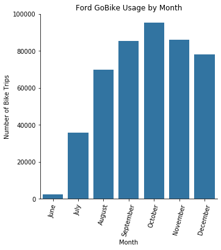

```python
#Month wise usage
color1 = sns.color_palette()[0]

month = ['June','July','August','September','October','November','December']

g = sns.catplot(data = df_clean, x = 'start_time_month', kind = 'count', color = color1, order=month);
g.set_axis_labels('Month', 'Number of Bike Trips'),
g.set_xticklabels(rotation=75);
plt.title('Ford GoBike Usage by Month');
```

- in this seven months highest peak is october which is early-mid autumn with highest popualarity to use Ford go. with second as September and November together.
- San Francisco is best in the mid-late summer as it usually stays sunny until returning to its usual foggy weather in the late autumn/early winter months.
- And temperature aint that hot compare to summer

**how is Day wise distribution and any outcomes?**

```python
df_clean.start_time_days.value_counts()
```

```
Tue    80482
Wed    80357
Thu    77198
Mon    73536
Fri    72018
Sat    36780
Sun    32788
Name: start_time_days, dtype: int64
```

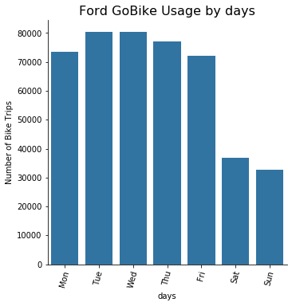

```python
# day wise usage distribution
days = ['Mon', 'Tue', 'Wed', 'Thu', 'Fri', 'Sat', 'Sun']

g = sns.catplot(data=df_clean, x='start_time_days', kind='count', color = color1, order = days)
g.set_axis_labels('days', 'Number of Bike Trips')
g.set_xticklabels(rotation=75)
plt.title('Ford GoBike Usage by days', fontsize=16);
```

**How Hour-wise distribution looks?**

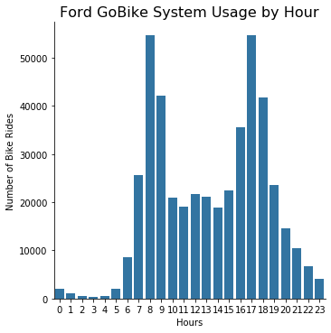

```python
# Hour wise usage
ax = sns.catplot(data = df_clean, x='start_time_hour', kind='count', color = color1)
ax.set_axis_labels('Hours', 'Number of Bike Rides')
plt.title('Ford GoBike System Usage by Hour', fontsize=16);
```

**Looking at travel distribution minutes wise**

```python
# looking duration of travel in minutes
df_clean.duration_min.describe()
```

```
count    453159.000000
mean         13.391000
std          42.089179
min           1.000000
25%           6.000000
50%           9.000000
75%          13.000000
max        1437.000000
Name: duration_min, dtype: float64
```

```python
# average travel time in minutes
df_clean.duration_min.mean()
```

```
13.390999627062467
```

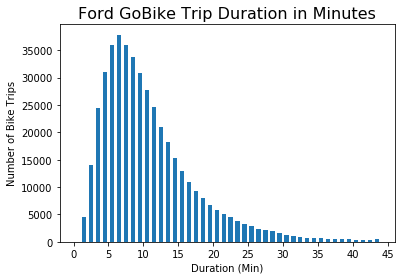

```python
# Duration of rides in minutes wise
bins = np.arange(0, 45, 1)
tic = [0, 5, 10, 15, 20, 25, 30,  35, 40, 45]
labels = ['{}'.format(val) for val in tic]

plt.hist(data = df_clean, x = 'duration_min', bins = bins, rwidth = 0.6);

plt.title("Ford GoBike Trip Duration in Minutes", fontsize=16)
plt.xlabel('Duration (Min)')
plt.xticks(tic, labels)
plt.ylabel('Number of Bike Trips');
```

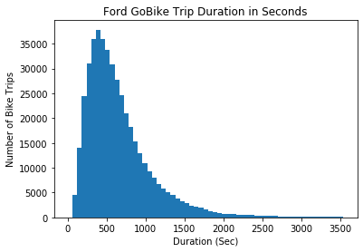

```python
# Duration of rides in sec wise
bin_edges = np.arange(0, 3600, 60)

plt.hist(data = df_clean, x = 'duration_sec', bins = bin_edges);

plt.title("Ford GoBike Trip Duration in Seconds")
plt.xlabel('Duration (Sec)')
plt.ylabel('Number of Bike Trips');
```

**Looking at distance travelled in ford go**

```python
df_clean.distance_km.describe()
```

```
count    453159.000000
mean          1.599335
std           0.983535
min           0.000000
25%           0.920390
50%           1.407962
75%           2.072494
max          62.293682
Name: distance_km, dtype: float64
```

```python
df_clean.distance_km.mean()
```

```
1.5993353642656163
```

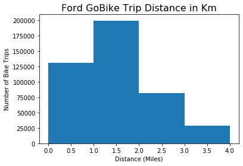

```python
# Distance in km traveled
bin_e = np.arange(0, 5, 1)

plt.hist(data = df_clean, x = 'distance_km', bins = bin_e);

plt.title("Ford GoBike Trip Distance in Km", fontsize=16)
plt.xlabel('Distance (Miles)')
plt.ylabel('Number of Bike Trips');
```

**Subscriber vs Customer**

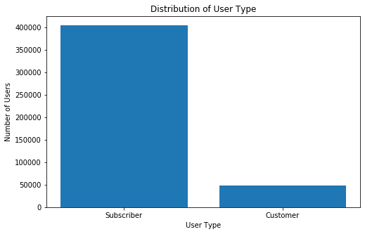

```python
# plotting types of users
plt.figure(figsize=[8,5])
plt.bar(x = df_clean.user_type.value_counts().keys(), height = df_clean.user_type.value_counts() )
plt.title('Distribution of User Type')
plt.xlabel('User Type')
plt.ylabel('Number of Users')
plt.show();
```

- 'Subscriber' user are more than 'Customer' user.

**Gender Distribution**

```python
# Using by females, males, and other
gender = df_clean.member_gender.value_counts()
gender
```

```
Male      348318
Female     98542
Other       6299
Name: member_gender, dtype: int64
```

[figure not shown]

```python
plt.pie(gender, labels = gender.index, startangle = 90, autopct= '%1.1f%%', counterclock = False, textprops={'color':'white'});

plt.title('Ford GoBike Users by Gender');
```

## Bivariate Exploration

**Customers vs Subscribers**

```python
# separate df of customer and subscriber
customer = df_clean.query('user_type == "Customer"')['bike_id'].count()
subscriber = df_clean.query('user_type == "Subscriber"')['bike_id'].count()
customer_prop = customer / df_clean['bike_id'].count()
subscriber_prop = subscriber / df_clean['bike_id'].count()
```

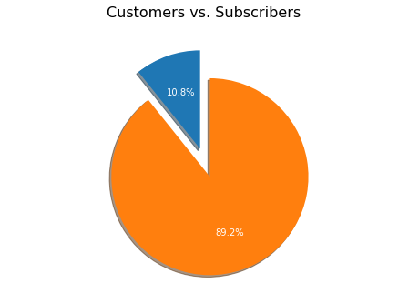

```python
# Pie chart customer and subscriber
plt.figure(figsize = [8, 5])

labels = ['Customer', 'Subscriber']
size = [customer_prop, subscriber_prop]
explode = (0, 0.3)

plt.pie(size, explode=explode, labels = labels, autopct='%1.1f%%', shadow=True, startangle=90, textprops={'color':'white'})
plt.axis('equal')

plt.suptitle('Customers vs. Subscribers', fontsize=16);
```

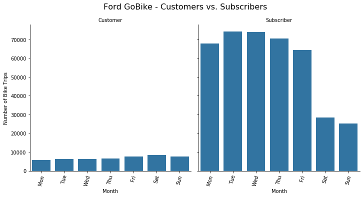

```python
# Customer Usage by daywise vs. Subscriber Usage by daywise

g = sns.catplot(data=df_clean, x='start_time_days', col="user_type", kind='count', order = days, sharey = True, color = color1);

g.set_axis_labels("Month", "Number of Bike Trips");
g.set_titles("{col_name}");

g.fig.suptitle('Ford GoBike - Customers vs. Subscribers', y=1.05, fontsize=16);
g.set_xticklabels(rotation=75);
```

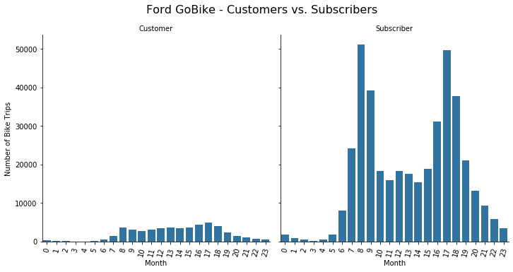

```python
# Customer Usage by time vs. Subscriber Usage by time
g = sns.catplot(data=df_clean, x='start_time_hour', col="user_type", kind='count', sharey = True, color = color1);

g.set_axis_labels("Month", "Number of Bike Trips");
g.set_titles("{col_name}");

g.fig.suptitle('Ford GoBike - Customers vs. Subscribers', y=1.05, fontsize=16);
g.set_xticklabels(rotation=75);
```

- In customer side hour wise most likely stable
- In subscriber side the peaks lies in start and end of work

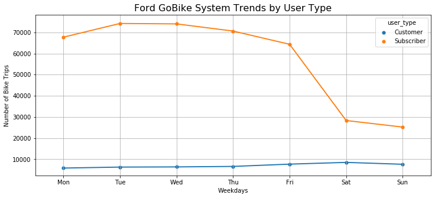

```python
# Customer Usage by Weekday vs. Subscriber Usage by Weekday
plt.figure(figsize=(12, 5))

df_cleaned_user_week = df_clean.groupby(['start_time_days', 'user_type']).size().reset_index()
weekday = ['Mon', 'Tue', 'Wed', 'Thu', 'Fri', 'Sat', 'Sun']

ax = sns.pointplot(data=df_cleaned_user_week, x='start_time_days', y=0, hue = 'user_type', scale=.7, order = weekday);

plt.title('Ford GoBike System Trends by User Type', fontsize=16)
plt.xlabel('Weekdays')
plt.ylabel('Number of Bike Trips')
plt.grid();
```

[figure not shown]

```python
# Customer Usage by Distance vs. Subscriber Usage by Distance
plt = df_clean.groupby('user_type')['distance_km'].mean().plot(kind='barh', figsize=(12,8));

plt.set_title('Average Distance (KM) by User Type')
plt.set_xlabel('User Type')
plt.set_ylabel('Average Distance Traveled (KM)');
```

- average distance of customer is slightly higher then subscriber

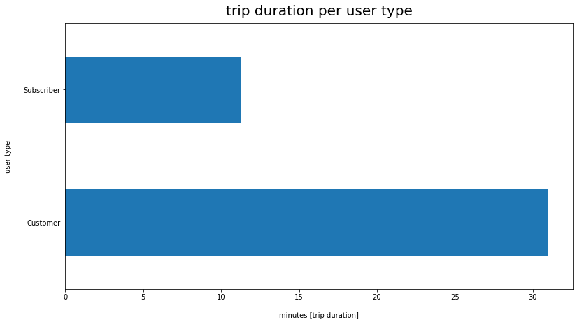

```python
## Average trip duration per user type
ax = df_clean.groupby('user_type')['duration_min'].mean().plot(kind='barh', color=color1, figsize=(13,7))
ax.set_title('trip duration per user type', fontsize=20, y=1.015)
ax.set_ylabel('user type', labelpad=16)
ax.set_xlabel('minutes [trip duration]', labelpad=16)
```

- since customer tends to ride more distance so more time too

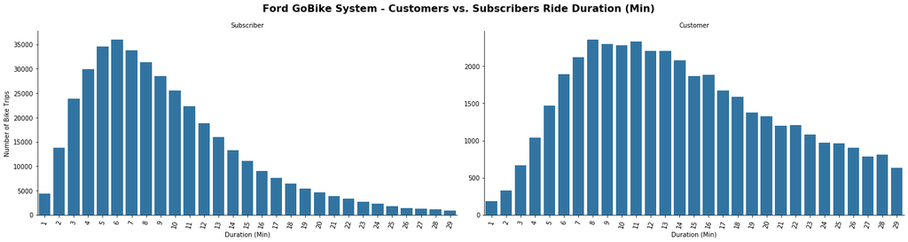

```python
# Customer Usage by Duration vs. Subscriber Usage by Duration
data = df_clean.query('duration_min < 30')

graph = sns.catplot(data=data, x = 'duration_min', col='user_type', kind='count', sharey = False, color = color1, height=5, aspect=2);

graph.set_axis_labels('Duration (Min)', 'Number of Bike Trips')
graph.set_titles('{col_name}')

graph.fig.suptitle('Ford GoBike System - Customers vs. Subscribers Ride Duration (Min)', y=1.05, fontsize=16, fontweight='bold');
graph.set_xticklabels(rotation=75);
```

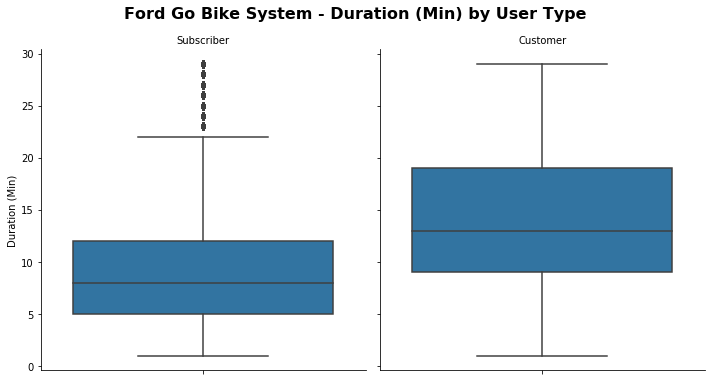

```python
#customer vs subscriber boxplot
data = df_clean.query('duration_min < 30')

g = sns.catplot(data=data, y='duration_min', col="user_type", kind='box', color = color1)

g.set_titles(col_template = '{col_name}')
g.set_axis_labels("", "Duration (Min)")
g.fig.suptitle('Ford Go Bike System - Duration (Min) by User Type', y=1.05, fontsize=16, fontweight='bold');
```

- customer of average rides more then 75% of subscriber

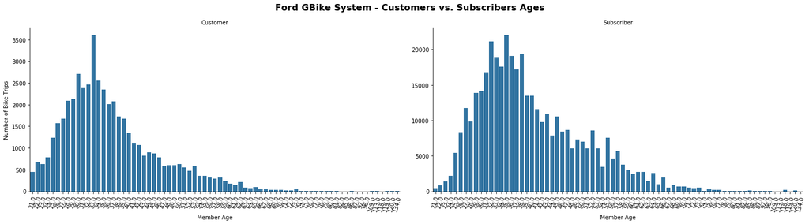

```python
# # Customer vs. Subscriber Usage by Age
graph = sns.catplot(data = df_clean, x = 'member_age', col='user_type', kind='count', sharey = False, color = color1, height=5, aspect=2)

graph.set_axis_labels('Member Age', 'Number of Bike Trips')
graph.set_titles('{col_name}')

graph.fig.suptitle('Ford GBike System - Customers vs. Subscribers Ages', y=1.05, fontsize=16, fontweight='bold');
graph.set_xticklabels(rotation=75);
```

```python
# plotting heatplot distributing values
all_numeric_vars = ['duration_sec', 'start_time', 'end_time', 'start_station_latitude', 'start_station_longitude', 'end_station_latitude',
'end_station_longitude', 'duration_min', 'distance_km']
numeric_vars = ['duration_min', 'distance_km']
categoric_vars = ['start_time_weekday'
                  , 'start_time_hour', 'user_type']
```

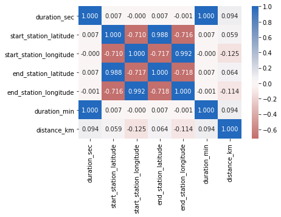

```python
# correlation plot
sns.heatmap(df_clean[all_numeric_vars].corr(), annot = True, fmt = '.3f', cmap = 'vlag_r', center = 0);
```

### some of the relationships you observed in this part of the investigation.

User type for the analysis revealed different behavior usage between customers and subscribers. The information proposes that customers are casual riders such as tourists, or students on a school vacation or holiday. This is precise when calculating in that Customer usage increases on the weekends. In contrast, the data suggests Subscribers are daily commuters or full time students who use the system during weekdays, better weather, and mostly for shorter distances. They mainly rent bikes before and after a typical work or school day (8-9am and 5-6pm).

User Type

- subscribers are:
  - more likey to take short trips
  - more likey to take short duration trips
- customers are:
  - more likey to take long length trips
  - more likey to take long duration trips

## Multivariate Exploration

```python
df_clean.member_age.describe()
```

[output not shown]

```python
# This highly unusual to ride a bike after 80 years so i vl be dropping all those with age > 80
df_clean.drop(df_clean[df_clean['member_age']>=80].index, inplace = True)
```

```python
# distribution age to age bins
df_clean['age_bins'] = df_clean['member_age'].apply(lambda x: '15 - 25' if 15<x<=25
                                                  else '26 - 35' if 25<x<=35
                                                  else '36 - 45' if 35<x<=45
                                                  else '46 - 55' if 45<x<=55
                                                  else '56 - 66' if 55<x<=66
                                                  else '66 - 80' if 66<x<=80
                                                      else x)
df_clean.age_bins.value_counts()
```

```
26 - 35    177876
36 - 45    146855
46 - 55     74507
56 - 66     33702
15 - 25     13993
66 - 80      5450
Name: age_bins, dtype: int64
```

```python
#Creating subscriber age df
subscriber_age_df = df_clean[df_clean['user_type'] == 'Subscriber'].groupby(['start_time_month', 'age_bins']).agg({'bike_id':'count'}).reset_index()
```

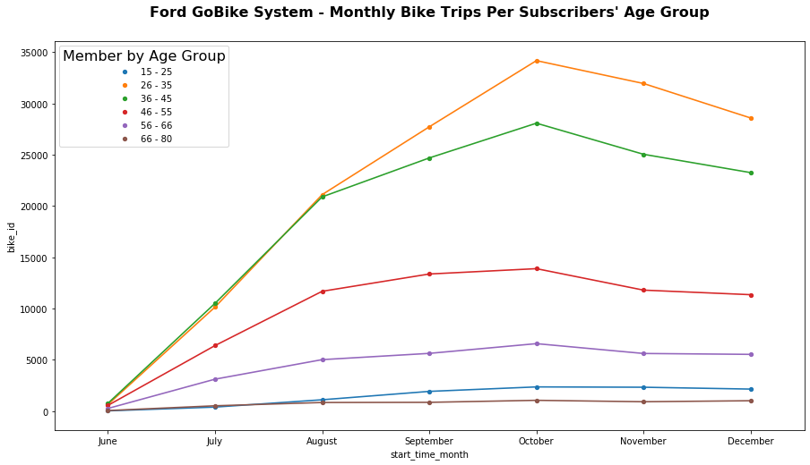

```python
# Comparing monthly number of bike trips per subscribers, on age group
import matplotlib.pyplot as plt
plt.figure(figsize = (15,8))

months = ['June', 'July', 'August', 'September', 'October', 'November', 'December']

ax = sns.pointplot(data = subscriber_age_df, x='start_time_month', y='bike_id', hue='age_bins', scale=.6, order = months, height=5, aspect=2);

ax.set_title("Ford GoBike System - Monthly Bike Trips Per Subscribers' Age Group", y = 1.05, fontsize = 16, fontweight = 'bold');
# Legend
leg = ax.legend()
leg.set_title('Member by Age Group', prop={'size': 16})
```

```python
#Creating Customer age df
customer_age_df = df_clean[df_clean['user_type'] == 'Customer'].groupby(['start_time_month', 'age_bins']).agg({'bike_id':'count'}).reset_index()
```

[figure not shown]

```python
# Comparing monthly number of bike trips per customers, on age bins
import matplotlib.pyplot as plt
plt.figure(figsize = (15,8))

months = ['June', 'July', 'August', 'September', 'October', 'November', 'December']

ax = sns.pointplot(data = customer_age_df, x='start_time_month', y='bike_id', hue='age_bins', scale=.6, order = months, height=5, aspect=2);

ax.set_title("Ford GoBike System - Monthly Bike Trips Per Customers' Age Group", y = 1.05, fontsize = 16, fontweight = 'bold');
# Legend
leg = ax.legend()
leg.set_title('Member by Age Group', prop={'size': 16})
```

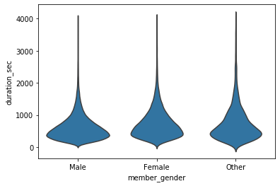

```python
# looking at duration_sec in genders
sns.violinplot(data = df.query("duration_sec <= 4039.5"),x = 'member_gender',y='duration_sec',color = sns.color_palette()[0],inner=None);
```

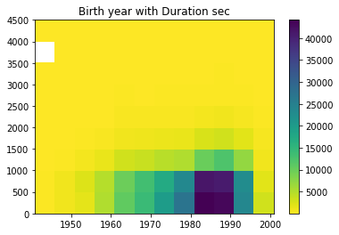

```python
# Relation of birth year with duration sec
xbin = np.arange(1941, df_clean['member_birth_year'].max()+5, 5)
ybin = np.arange(0, 4039.5+500, 500)
plt.hist2d(data = df_clean,x = 'member_birth_year',y='duration_sec',cmin=0.5,cmap = 'viridis_r',bins=[xbin, ybin]);
plt.colorbar()
plt.title('Birth year with Duration sec');
```

- there is high concentration young people(1980-2000) that have a travel duration between 0-1250~s

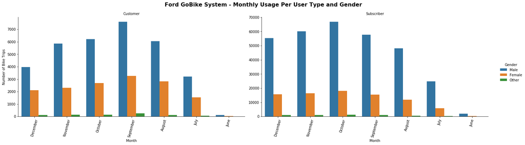

```python
# Monthly usage - user type and gender
graph = sns.catplot(data=df_clean, x='start_time_month', col="user_type", hue="member_gender", kind='count', sharey = False, height=5, aspect=2);

graph.set_axis_labels("Month", "Number of Bike Trips")
graph._legend.set_title('Gender')
graph.set_titles("{col_name}")

graph.fig.suptitle('Ford GoBike System - Monthly Usage Per User Type and Gender', y=1.05, fontsize=16, fontweight='bold');
graph.set_xticklabels(rotation=75);
```

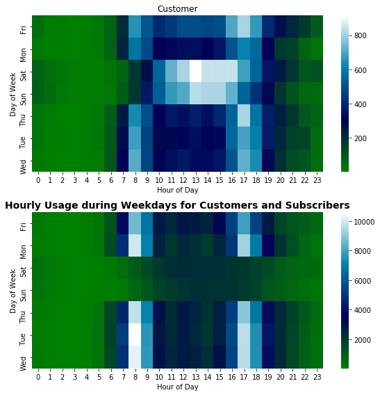

```python
# Figure
plt.figure(figsize=[8, 8]);
# first subplot
plt.subplot(2, 1, 1)
customers = df_clean.query('user_type == "Customer"')
customers_df = customers.groupby(['start_time_days', 'start_time_hour']).size()
customers_df = customers_df.reset_index(name='count')
customers_df = customers_df.pivot(index='start_time_days', columns='start_time_hour', values='count')
sns.heatmap(customers_df, cmap='ocean');
plt.title('Customer', loc='center');
plt.xlabel('Hour of Day');
plt.ylabel('Day of Week');
plt.tight_layout();
# second subplot
plt.subplot(2, 1, 2)
subscribers = df_clean.query('user_type == "Subscriber"')
subscriber_df = subscribers.groupby(['start_time_days', 'start_time_hour']).size()
subscriber_df = subscriber_df.reset_index(name='count')
subscriber_df = subscriber_df.pivot(index='start_time_days', columns='start_time_hour', values='count')
sns.heatmap(subscriber_df, cmap='ocean');
plt.title('Subscriber', loc='center');
plt.xlabel('Hour of Day');
plt.ylabel('Day of Week');
plt.tight_layout();
plt.title('Hourly Usage during Weekdays for Customers and Subscribers', fontsize=14, fontweight='semibold', y=1.015);
```

## Summary

From the plot Subscribers that are aged in group between 26-35 years old are the most common age group to use the bike sharing system. The 26-35 years old also tends lead the spike which occurs across all age groups in October As these age are the working age. Subscribers who fall in the 36-45 year old age group are the next most common age group to use the bike sharing system, and follow a similar trend at the 26-35 year olds.

Glancing back at plots, jumping for other sexual orientation at a more established is an astonishment. Furthermore, for supporters the outing length is higher than client for more established age is a shock